# Laboratorium przetwarzania obrazów i grafiki komputerowej

## Sesja 3 - Operacje punktowe na obrazach

### Łódź 2017

### Zadania do wykonania

#### 1. Obrazy do pracy podczas laboratrium

Ze [strony domowej przedmiotu](http://www.eletel.p.lodz.pl/med/pl/index.php?option=com_jotloader&view=categories&cid=99_b3c1de9aa6c8258566cc1b3370d1e750&Itemid=346) pobierz plik *lab3.zip*. Plik zapisz **w swoim katalogu roboczym** na dysku *D:\* , a następnie rozpakuj. Użyj programu *7zip* lub polecenia systemowego *Wyodrębnij wszystkie...*.

#### 2. Importowanie bibliotek systemowych

Zaimportuj wszystkie pakiety systemowe, które będą wykorzystywane podczas wykonywania ćwiczenia.

```python
import os
import numpy as np
import scipy.misc as misc
import matplotlib.pyplot as plt
```

#### 3. Wybór metody wyświetlania obrazów

Podczas wykonywania ćwiczenia sugerowana jest wyświetlanie wyników **w oknach zewnętrznych**.

```python
# wyświetlanie w osobnym, niezależnym oknie
#%matplotlib qt
# wyświetlanie wewnątrz dokumentu
%matplotlib inline
```

#### 4. Importowanie bibliotek własnych

Jeżeli korzystasz z własnych modułów lub pakietów również trzeba ja dołączyć.

Do ponownego zaimportowania modułu nie wystarczy ponowne użycie słowa kluczowego *import* wraz z nazwą modułu. Trzeba "wymusić" ponowne załadowanie klas, funkcji, zmiennych zdefionowanych w utworzonej wcześniej bibliotece za pomocą runkcji *reload()*.

Uwaga! Moduły *poigk_lab1.py* oraz *poigk_lab2.py* zostały napisane przez prowadzącego zajęcia i nie są dostępne na komputerach Studenckich. W trackie zajęć można zapisać tworzone funkcje we własnych modlułach w celu ich późniejszego, wielokrotnego wykorzystania. Nie należy importować pakietu *poigk_lab1* i *poigk_lab2* podczas pracy na laboratoriach.

```python
import poigk_lab1 as poigk1
import poigk_lab2 as poigk2
import poigk_lab3 as poigk3
```

#### 5. Wczytanie i wyświetlenie obrazu z pliku dyskowego

Wczytaj jeden z obrazów dostępnych w katalogu z danymi (np. *bled2_gray.png*). W tym celu użyj funkcji *imread()* z biblioteki *scipy.misc*. Zachowaj kopie obrazu wczytanego (oryginalnego) w zmiennej *img_wczyt*.

```python
# pliki z obrazami RGB dostępne w katalogu z danymi do laboratorium nr 3 (lab3_dane)

# bled1_gray.png, bled2_gray.png, bratek_gray.png, krynica_gray.png, lisc_gray.png, praga_gray.png,
# santamonica1_gray.png, santamonica2_gray.png, seattle_gray.png, tampere_gray.png, zagrzeb_gray.png

filename = 'bled2_gray'
filenameext = filename + '.png'
pathtofile = os.path.join('lab3_dane',filenameext)
im_gray = misc.imread(pathtofile)
im_wczyt = im_gray.copy()
```

#### 6. Rozciąganie histogramu

Wypisz informacje o obrazie. Zwróć uwagę na wartości minimalną i maksymalna.

Czy jest wykorzystany pełen zakres wszystkich dostępnych wartości macierzy (jasności obrazu)?

Zastosuj funkcje *rescaleFor()* aby wykorzystać wszystkie dostępne poziomy jasności. Operacja ta nosi nazwę *rozciągania poziomów jasności*. Jaki zakres jasności jest dostępny dla obrazów z elemetnami typu *uint8* a jaki dla obrazów typu *float32*?

Wyświetl obok siebie obydwa obrazy oraz ich histogramy. Porównaj wizualnie obrazy i ich histogramy. Sprawdź wartości minimalne i maksymalne w obu obrazach.

```python
poigk2.imginfo2(im_wczyt,'Wczytany')
```

```
info o WCZYTANY: min=72.00, max=244.00, br.=153.694, con.=45.101 shape=(478, 640), dtype=uint8
```

```python
poigk2.rescaleFor(im_gray, 0, 255)
poigk2.imginfo2(im_gray,'reskalowany')
```

```
info o RESKALOWANY: min=0.00, max=255.00, br.=120.623, con.=66.865 shape=(478, 640), dtype=uint8
```

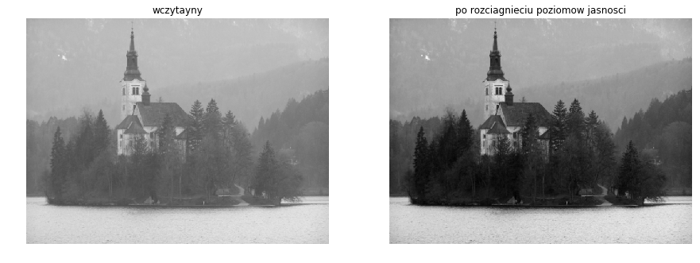

```python
plt.figure(figsize=(15,10))
plt.subplot(121)
plt.imshow(im_wczyt,vmin=0,vmax=255,cmap='gray')
plt.title('wczytayny')
plt.axis('off')
plt.subplot(122)
plt.imshow(im_gray,vmin=0,vmax=255,cmap='gray')
plt.title('po rozciagnieciu poziomow jasnosci')
plt.axis('off')
plt.show()
```

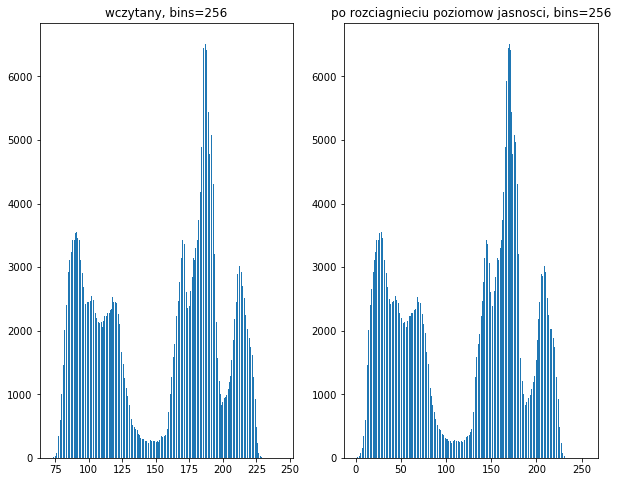

```python
poigk2.hist2([im_wczyt,im_gray],bins=[256,256],titles=['wczytany','po rozciagnieciu poziomow jasnosci'])
```

#### 7. Rozciąganie histogramu - program Fiji

Zapoznaj się z działaniem funkcji rozciągania i wyrównywania histogramu zaimplementowanymi w programie *Fiji* (Process->Enhance contrast). Zastosuj te procedury dla kliku wybranych obrazów z katalogu *lab3_dane* (*bled1_gray.png*, *bled2_gray.png*, *seattle_gray.png*).

#### 7. Inwersja poziomów jasności

Dokonaj inwersji jasności obrazu. W tym celu od watości maksmyalnej (*wmax*) odejmij warośc każdego piksela.

- dla *uin8* wmax wynosi 255,
- dla *float32* przyjmuje się że wmax=1.0 gdy jasność obrazu jest zakresu $0\div1$.

```python
im_gray_inv = 255 - im_gray
```

```python
poigk2.imginfo2(im_gray, 'Po rozciagnieciu poziomow jasnosci')
poigk2.imginfo2(im_gray_inv,'Po inwersji poziomow jasnosci')
```

```
info o PO ROZCIAGNIECIU POZIOMOW JASNOSCI: min=0.00, max=255.00, br.=120.623, con.=66.865 shape=(478, 640), dtype=uint8
info o PO INWERSJI POZIOMOW JASNOSCI: min=0.00, max=255.00, br.=134.377, con.=66.865 shape=(478, 640), dtype=uint8
```

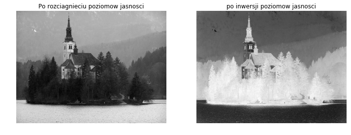

```python
poigk1.imshow2([im_wczyt, im_gray_inv],
               titles=['Po rozciagnieciu poziomow jasnosci','po inwersji poziomow jasnosci'],show_axis='off')
```

#### 9. Liniowa i nieliniowa zmiana jasności

Wczytaj jeden z obrazów dostępnych w katalogu z danymi (np. *santamonica2_gray.png*). W tym celu użyj funkcji *imread()* z biblioteki *matplotlib.pyplot*. Zachowaj kopie obrazu wczytanego (oryginalnego) w zmiennej *img_wczyt*.

Wypisz podstawowe informacje o obrazie i wyświetl go.

```python
filename = 'santamonica2_gray'
filenameext = filename + '.png'
pathtofile = os.path.join('lab3_dane',filenameext)
im_gray = plt.imread(pathtofile)
im_wczyt = im_gray.copy()
```

```python
poigk2.imginfo2(im_wczyt, 'wczytany')
```

```
info o WCZYTANY: min=0.00, max=1.00, br.=0.200, con.=0.190 shape=(425, 640), dtype=float32
```

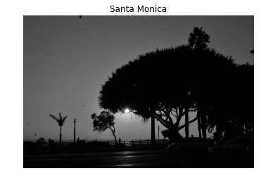

```python
plt.figure()
plt.imshow(im_wczyt, cmap='gray')
plt.title('Santa Monica')
plt.axis('off')
plt.show()
```

Do wczytanego obrazu zastosuj następujące operacje matematyczne w odniesieniu do wartości macierzy (czyli w odniesieniu do jasności pikseli obrazu):

- $y=2\cdot x$
- $ y = x^2$
- $ y = \sqrt x$
- $ y = log(x) $

Wypisz informacje o obrazach po zastosowaniu wszystkich operacji matematycznych.

Wyświetl obrazy.

```python
podwojony = 2*im_gray
kwadrat = im_gray**2
pierwiastek = np.sqrt(im_gray)
log = np.log(im_gray)
```

```python
poigk2.imginfo2(podwojony,'2x')
poigk2.imginfo2(kwadrat,'kwadrat')
poigk2.imginfo2(pierwiastek,'pierwiastek')
poigk2.imginfo2(log,'log')
```

```
info o 2X: min=0.01, max=2.00, br.=0.400, con.=0.380 shape=(425, 640), dtype=float32
info o KWADRAT: min=0.00, max=1.00, br.=0.076, con.=0.089 shape=(425, 640), dtype=float32
info o PIERWIASTEK: min=0.06, max=1.00, br.=0.363, con.=0.261 shape=(425, 640), dtype=float32
info o LOG: min=-5.54, max=0.00, br.=-2.865, con.=2.040 shape=(425, 640), dtype=float32
```

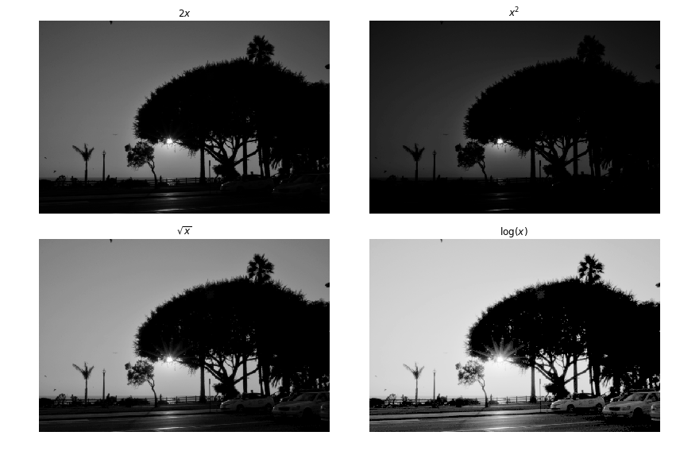

```python
poigk1.imshow4([podwojony,kwadrat,pierwiastek,log],show_axis='off',
                                           titles=['$2x$','$x^2$','$\sqrt{x}$','$\log(x)$'])
```

1. w tym przypadku do wczytania obrazu wykorzystaliśmy funkcję *imread()* z pakietu *matplotlib.pyplot* a nie z pakietu *scipy.misc*?
2. Czy zawsze możemy wykonywać dowone funkcje matematyczne w odniesieniu do jasności obrazów?
3. O czym trzeba pamiętać przed każdą zmianą jasnośći obrazu?
4. Jakie kroki trzeba podjąć aby wynik takich dzaiłań był poprawny?
5. Sprawdź jak się zmieniły histogramy obrazów po transformacjach.
6. Zastosuj podobne operacje do kilku innych obrazów, które znajdują się w katalogu *lab3_dane*.
   - bled2_gray.png
   - bratek_bray.png
   - seattle_gray.png
   - tampere_gray.png
   - zagrzeb_gray.png

#### 10. Progowanie obrazu - program ImageJ-Fiji

Dla wybranych obrazów w katalogu z danymi (*lab3_dane*) przetestuj algorytm progowania dostępny w programie ImageJ-Fiji (Image->Adjust->Threshold). Sprawdź rezultaty progowania przy zmianie zarówno dolnej jak i górnej wartości progu. Przed progowaniem wyświetl histogramy obrazów wczytanych i postaraj się ustalić wartości optymalnych progów na podstawie wyglądu histogramu.

AutoThreshold -> AutoLocalThreshold

#### 11. Progowanie obrazu - algorytmy

Wypisz podstawowe informacje o obrazie i wyświetl go.

```python
filename = 'krynica_gray'
filenameext = filename + '.png'
pathtofile = os.path.join('lab3_dane',filenameext)
im_gray = misc.imread(pathtofile)
im_wczyt = im_gray.copy()
```

```python
poigk2.imginfo2(im_wczyt, 'lisc-wczytany')
```

```
info o LISC-WCZYTANY: min=3.00, max=237.00, br.=122.134, con.=65.757 shape=(722, 480), dtype=uint8
```

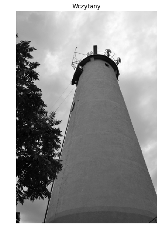

```python
plt.figure(figsize=(10,8))
plt.imshow(im_wczyt, cmap='gray')
plt.title('Wczytany')
plt.axis('off')
plt.show()
```

Progowanie ([wykład-ang](http://eletel.p.lodz.pl/pstrumil/ang_po/segmentation.pdf), [wykład-pl](http://eletel.p.lodz.pl/pstrumil/po/analiza.pdf)) jest jedną z podstawowych operacji na pikselach obrazu. Celem progowania jest segmentacja obrazu, czyli oddzielenie szukanego obiektu odwzorowanego w obrazie od otaczającego tła.

Ponieważ jest to bardzo prosta, a zarazem podstawowa metoda segmentacji zapoznamy się z 3 sposobami jej realizacji. W dwóch przypadkach napiszemy własne funkcje. Zadbaj o to aby funkcje te nie operowały na obrazie oryginalnym *im_gray*.

1. Funkcja *thresh1()* z wykorzystaniem dwóch pętli *for* - do samodzielnego zaimplementowania.
2. Funkcja *thresh2()* z wykorzystaniem operacji macierzowych (kod poniżej).
3. Funkcja *where()* z biblioteki *numpy*.

```python
# mteoda 2
def thres2(img,th,outMin=0, outMax=255):
    im = img.copy()
    im[im>=th] = outMax
    im[im<th] = outMin
    return im
```

```python
# metoda 3
th = 128
im_th = np.where(im_gray >= th,255,0)
```

Wykonaj progowanie wczytanego wszystkimi metodami i wyśietl obrazy wynikowe obok siebie. Porównaj również informacje o paramterach trzech obrazów.

```python
# metoda 1
th1 = poigk3.thresh1(im_gray,128)
# metoda 2
th2 = poigk3.thres2(im_gray,128)
# metoda 3
th3 = np.where(im_gray>=128, 255,0)
```

```python
poigk2.imginfo2(th1, 'th1')
poigk2.imginfo2(th2, 'th2')
poigk2.imginfo2(th3, 'th3')
```

```
info o TH1: min=0.00, max=255.00, br.=103.462, con.=125.214 shape=(722, 480), dtype=uint8
info o TH2: min=0.00, max=255.00, br.=103.462, con.=125.214 shape=(722, 480), dtype=uint8
info o TH3: min=0.00, max=255.00, br.=103.462, con.=125.214 shape=(722, 480), dtype=int64
```

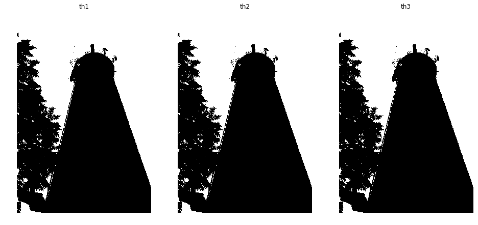

```python
poigk1.imshow3([th1,th2,th3],show_axis='off',titles=['th1','th2','th3'])
```

#### 12. Zmiana wartości globalnej progu

Oceń wyniki "wizualnie".

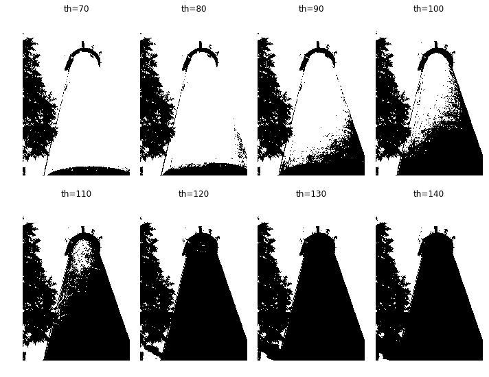

```python
plt.figure(figsize=(10,8))
for i,th in enumerate(range(70,141,10)):
    plt.subplot(2,4,i+1)
    plt.imshow(np.where(im_gray>=th,255,0),cmap='gray')
    plt.title('th=%d'%th)
    plt.axis('off')
plt.tight_layout()
plt.subplots_adjust(wspace=0.1,hspace=0.01)
plt.show()
```

Aby mieć dostęp do obrazów binarnych w celu ich dalszego przetwarzania lub analizy, wykonaj progowanie ponownie i zachowaj wyniki np. w obiekcie typu *lista*. W tym celu użyj *listy składanej* (ang. *list comprehension*).

Dla każdej wartości progu wypisz jaki procent obrazu stanowi obiekt zaklasyfikowany jako "liście".

Poniżej zaproponowano rozwiązanie tego zadania z wykorzystaniem funkcji *np.nonzero()*. Postaraj się przeprowadzić takie same obliczenia z wykorzystaniem:

- sposobu macierzowego im[im==255] tak jak w funkcji *thresh2()*
- funkcji *np.where()*

```python
obr = [np.where(im_gray>th,255,0) for th in range(60,131,10)]
```

```python
ths = range(70,141,10)
for nr,o in enumerate(obr):
    print "Dla progu o wartości th=%d liście stanowią %.0f proc. powierzchni całego obrazu." \
                                                % (ths[nr],(1.0-o[np.nonzero(o)].size / float(o.size)) * 100)
```

[output not shown]

#### 13. Dobór optymalnego progu

Na podstawie obserwacji histogramu, postaraj się określić optymalny próg, który pozwoli na oddzielenie liści od tła.

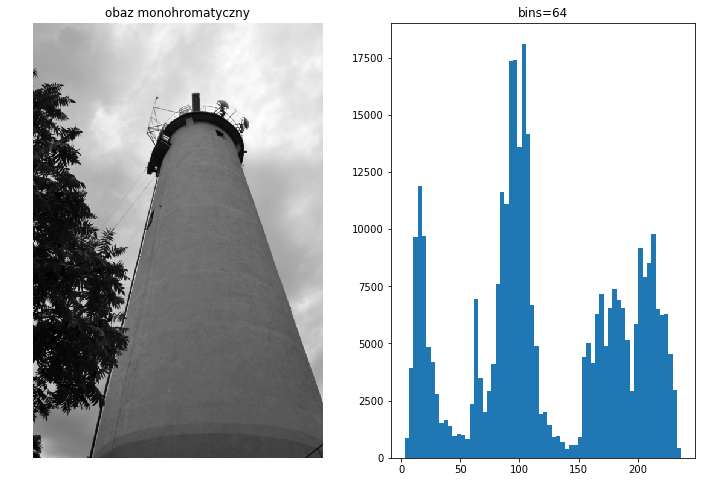

```python
poigk2.img_hist(im_gray,title='obaz monohromatyczny',show_axis='off')
```

Do tego zadania pomocny może okazać się przykład z przedmiotu *Podstawy programowania* dotyczący interakcyjnego progowania obrazu z wykorzystaniem suwaka. Program napisano z wykorzystaniem biblioteki *matplotlib*.

Sprawdź jak wygląda obraz po progowaniu dla wartości progu równego średniej wartości jasności obrazu wczytanego.

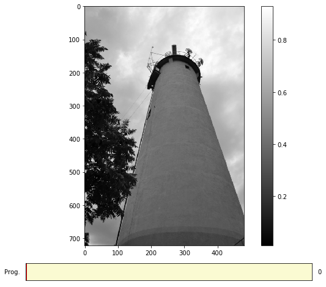

```python
# %load poigk_lab3_progowanie_2d.py
# Lab 9 - 2015
# Matplotlib - Graficzny interfejs użytkownika 2- biblioteka Matplotlib
# (c) Marek Kocinski & Anna Borowska-Terka

import os
import numpy as np
import matplotlib.pyplot as plt
from matplotlib.widgets import Slider

img = plt.imread(os.path.join('lab3_dane','krynica_gray.png'))


fig = plt.figure(figsize=(10,8))
ax = fig.add_subplot(111)
fig.subplots_adjust(bottom=0.2)

im = ax.imshow(img,cmap='gray')
fig.colorbar(im)

slidercolor = 'lightgoldenrodyellow'
slideraxes = fig.add_axes([0.25, 0.1, 0.65, 0.05], axisbg=slidercolor)

slider = Slider(slideraxes, 'Prog.', 0, 255, valinit=img.max()/2, valfmt='%d')

def update(val):
    im.set_array(np.where(img>slider.val,255,0))
    fig.canvas.draw()

slider.on_changed(update)
plt.show()
```

#### Zadania dodatkowe do wykonania podczas zajęć lub w domu

#### 14. Adaptacyjny dobór wartości progu

Zastosuj algorytm adaptacyjengo doboru progu przedstawiony w przykładzie na [stronie scikit-image](http://scikit-image.org/docs/0.9.x/auto_examples/plot_threshold_adaptive.html) do wybranych obrazów testowych. Porównaj wyniki w odniesieniu do progowanie z globalną wartością progu dla całego obrazu.

Zapoznaj się z metodą progowania zaproponowaną przez [Nobuyuki Otsu](https://en.wikipedia.org/wiki/Otsu%27s_method).

#### 15. Wyznaczanie współczynników podobieństwa

Zapoznaj się z definicją współczynników Jaccarda ([wiki ang](https://en.wikipedia.org/wiki/Jaccard_index),[wiki pl](https://pl.wikipedia.org/wiki/Indeks_Jaccarda)) i Dice'a ([wiki ang](https://en.wikipedia.org/wiki/Sørensen–Dice_coefficient),[wiki pl](https://pl.wikipedia.org/wiki/Współczynnik_Sørensena)). Wyznacz jeden z tych współczynników dla serii obrazów sprogowanych z różną wartością progu. Za obraz odniesienia przyjmij ten dla którego wartość progu jest równa wartości średniej jasności w obrazie.

#### 16. Rozrost obszaru od zarodka

Zaimplementuj algorytm *rozrostu obszaru od zarodka*. Algorytm sprawdzajasność wybranego piksela oraz wszystkich jego sąsiadów. Jeżeli jsaność piksela sąsiedniego jest taka sama jak jasność bieżącego pikslea (lub zawiera się w określonych granicach) to piksel sąsiedni zostanie zakwalifikowany do szukanego obszaru. Gdy jasność piksela sąsiadniego nie jest równa jasności bieżącego piksela (lub nie mieści się w zadanym przedaiale jasnośći) piksel ten zostanie zakwalifikowany do tła. Algorytm powinien zwrócić nowy obraz z zaznaczonymi indeksami pikseli zakwalikowanych do szukanego obszaru.

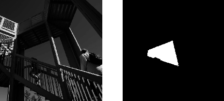

```python
from IPython.display import Image
seed = Image('obrazy_2017/lab3_seed_growing.png')
seed
```

#### Ostatnia aktualizacja 13.04.2017